# Tissue and cell type specificity analysis

Amy Hicks

29/09/2022

This markdown contains an exploration of the tissue- and cell-type specificity of non-specific lethal (NSL) complex genes. TPM values were obtained from the [GTEx portal](https://www.gtexportal.org/home/multiGeneQueryPage) denoting the relative expression across 13 different CNS regions and single-cell nuclear RNA-sequencing data from **substantia nigra** and **middle temporal gyrus** (MTG) were obtained from [Argwal et al., 2020](https://www.ncbi.nlm.nih.gov/pmc/articles/PMC7442652/) and the [Allen Brain Atlas](https://celltypes.brain-map.org/rnaseq/human/mtg) respectively. The `MarkerGenes` repository was cloned from [Regina's github](https://github.com/RHReynolds/MarkerGenes.git) and functions were run locally.

# 1. Set up

Source data was obtained from the [GTEx portal](https://www.gtexportal.org/home/multiGeneQueryPage) and the `MarkerGenes` repository cloned from [Regina's github](https://github.com/RHReynolds/MarkerGenes.git).

```r
# Load TPMs
NSL_gtex_tissueexp <- read_excel(file.path(here::here("data", "NSL_gtex_tissueexp.xlsx")))
# Load specificity matrices
load(file.path(here::here("data/MarkerGenes_source/AIBS2018_MTG.rda")))
load(file.path(here::here("data/MarkerGenes_source/Agarwal2020_SNIG.rda")))
# Import lists of genes of interest
NSL_file <- read.csv(file.path(here::here("data/Gene_lists/NSL_genes.csv")))
names(NSL_file)[names(NSL_file)=="Symbol"] <- "Gene_symbol"
NSL_genes <- as.character(NSL_file$Gene_symbol)
# functions
source(file.path(here::here("scripts/MarkerGenes_source/query_gene_ctd.R")))
source(file.path(here::here("scripts/MarkerGenes_source/reorder_within.R")))
source(file.path(here::here("scripts/MarkerGenes_source/summarise_specificity_plot.R")))
```

# 2. Tissue specificty

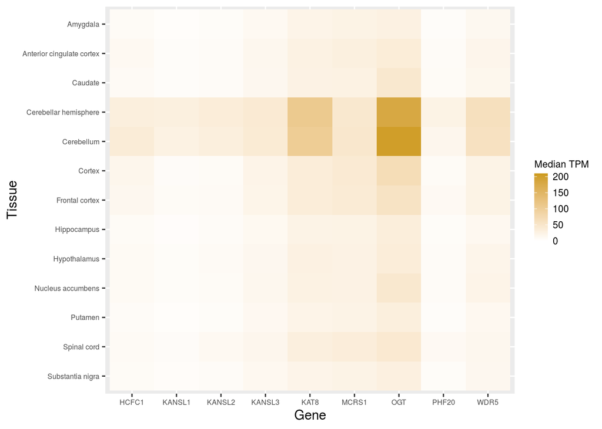

```r
# Format for plot
NSL_gtex_tissueexp$Median_TPM <- as.numeric(NSL_gtex_tissueexp$Median_TPM)
NSL_gtex_tissueexp <- dplyr::arrange(NSL_gtex_tissueexp, Tissue)
NSL_gtex_tissueexp$position <- nrow(NSL_gtex_tissueexp):1
# Plot
ggplot(NSL_gtex_tissueexp, aes(Gene, reorder(Tissue, position))) +
  geom_tile(aes(fill = Median_TPM)) +
  scale_fill_gradient(low = "white", high = "goldenrod3", limits = c(0,210)) +
  labs(y = "Tissue", fill = "Median TPM") +
  theme(
    axis.text = element_text(size = 6),
    legend.title = element_text(size = 8),
    legend.text = element_text(size = 8),
    legend.key.size = unit(4, "mm"))
```

# 3. Cell type specificty

`query_gene_ctd`, `reorder_within` and `scale_x_reordered` functions were loaded locally.

```r
# Query gene list
specificity <- query_gene_ctd(genes = NSL_genes,
                              ctd_Agarwal2020_SNIG, ctd_AIBS2018,
                              celltypeLevel = 1,
                              median_included = FALSE,
                              genelistSpecies = "human",
                              ctdSpecies = "human")
specificity$CellType <- as.character(specificity$CellType)
specificity$CellType[specificity$CellType=="ODC"] <- "Oligodendrocytes"
specificity$CellType[specificity$CellType=="Oligodendrocyte"] <- "Oligodendrocytes"
specificity$CellType[specificity$CellType=="Astrocyte"] <- "Astrocytes"
specificity$CellType[specificity$CellType=="GABA"] <- "GABAergic neurons"
specificity$CellType[specificity$CellType=="GABAergic"] <- "GABAergic neurons"
specificity$CellType[specificity$CellType=="Endothelial cell"] <- "Endothelial cells"
specificity$CellType[specificity$CellType=="Endothelial"] <- "Endothelial cells"
specificity$CellType[specificity$CellType=="DaNs"] <- "Dopaminergic neurons"
specificity$CellType[specificity$CellType=="Glutamatergic"] <- "Glutamatergic neurons"
specificity$CellType[specificity$CellType=="OPC"] <- "Oligodendrocyte precursor cells"
specificity$Study[specificity$Study=="ctd_Agarwal2020_SNIG"] <- "Substantia nigra"
specificity$Study[specificity$Study=="ctd_AIBS2018"] <- "Medial temporal gyrus"
colnames(specificity)[colnames(specificity)=="Study_species"] <- "Species"
```

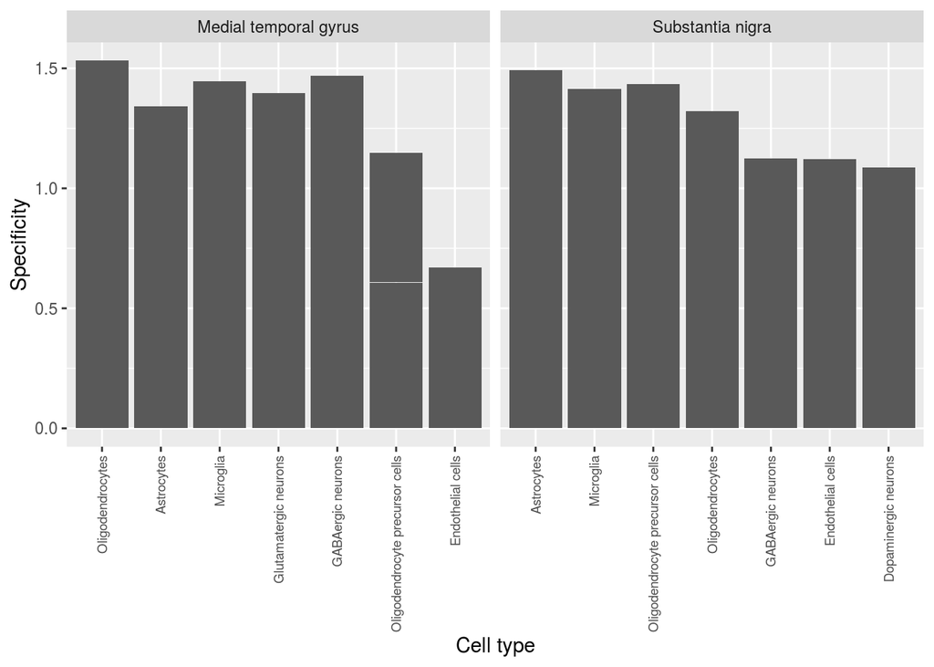

```r
# Plot bar plots
specificity %>%
  ggplot(aes(x = reorder_within(x = CellType,
                                by = Specificity,
                                within = Study,
                                fun = median,
                                desc = TRUE),
             y = Specificity)) +
  geom_col() +
  scale_x_reordered() +
  facet_wrap(~ Study, scales = "free_x") +
  labs(x = "Cell type") +
  theme(axis.text.x = element_text(angle = 90, size = 7, hjust = 1, vjust = 0.5))
```

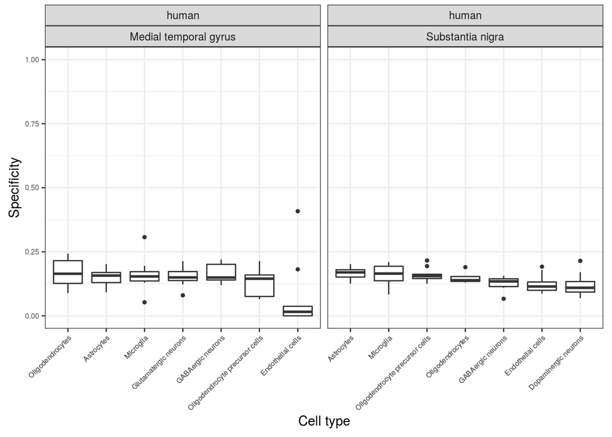

```r
# Blot box and whisker
summarise_specificity_plot(specificity)
```

## Substantia nigra

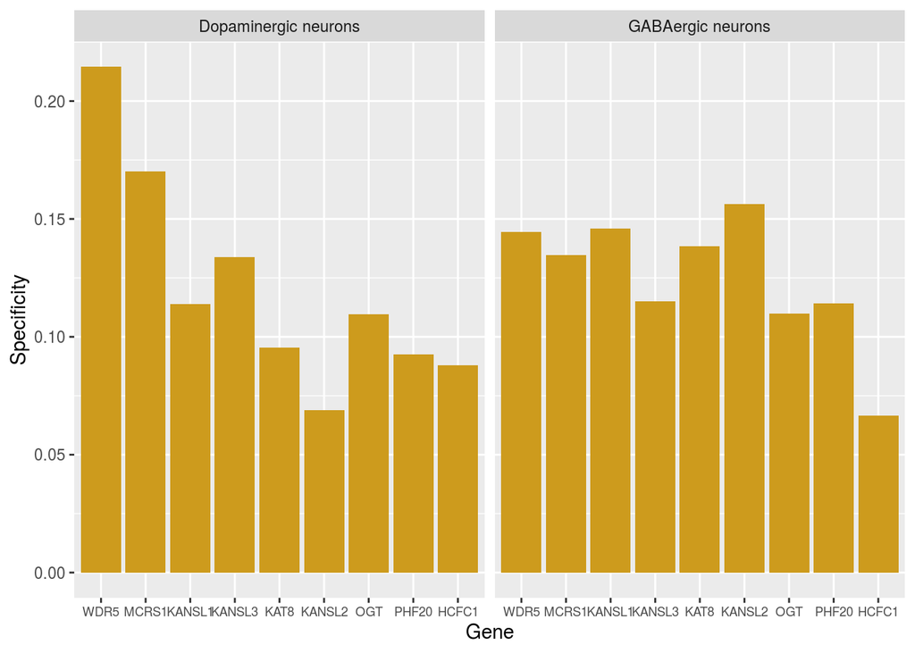

```r
# Plot just substantia nigra neurons
specificity %>%
  dplyr::filter(Study == "Substantia nigra") %>%
  dplyr::filter(CellType %in% c("Dopaminergic neurons", "GABAergic neurons", "Glutamatergic neurons")) %>%
  ggplot(aes(x = reorder_within(x = Gene,
                                by = Specificity,
                                within = Study,
                                fun = median,
                                desc = TRUE),
             y = Specificity)) +
  geom_col(fill = "goldenrod3") +
  scale_x_reordered() +
  facet_wrap(~ CellType, scales = "free_x") +
  labs(x = "Gene") +
  theme(axis.text.x = element_text(size = 7))
```

These values were compared to the specificity of the rest of the genes within the dataset by plotting their quantiles (each gene is assigned to a bin, 1-40). The dotted line at 20 indicates the median mark.

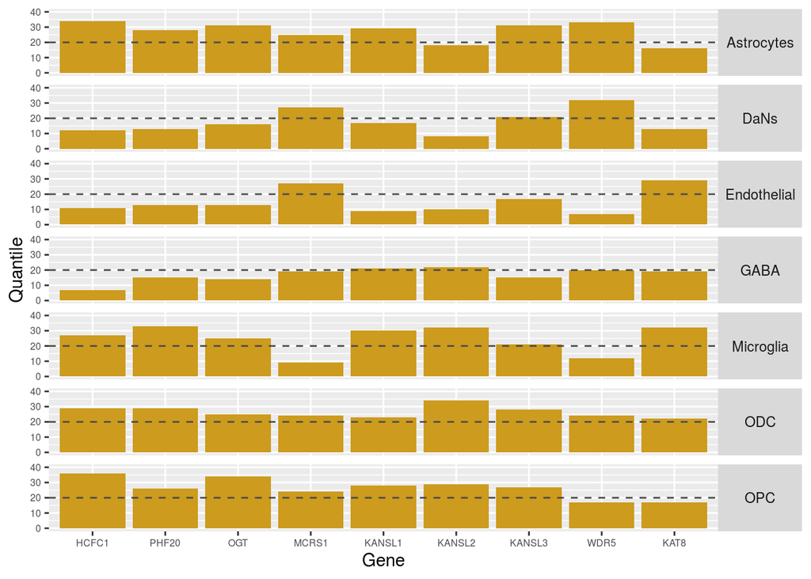

```r
# Quantiles
sn_quantiles <- as.data.frame(ctd_Agarwal2020_SNIG[[1]]$specificity_quantiles)
sn_quantiles <- rownames_to_column(sn_quantiles, var = "Gene")
sn_quantiles2 <- sn_quantiles %>%
  tidyr::gather(key = CellType, "Quantile", 2:8) %>%
  dplyr::mutate(Species = c("human")) %>%
  dplyr::mutate(Study = c("Substantia nigra"))
# Filter for NSL genes
sn_quantiles2 %>%
  dplyr::filter(Gene %in% NSL_genes) %>%
  ggplot(aes(x = reorder_within(x = Gene,
                                by = Quantile,
                                within = Study,
                                fun = median,
                                desc = TRUE),
             y = Quantile)) +
  geom_col(fill = "goldenrod3") +
  geom_hline(yintercept = 20, linetype = "dashed", color = "gray30") +
  ylim(0,40) +
  scale_x_reordered() +
  facet_grid(CellType ~., scales = "free", space = "free") +
  labs(x = "Gene") +
  theme(strip.text.y = element_text(angle = 0), axis.text = element_text(size = 6))
```

## Medial temporal gyrus

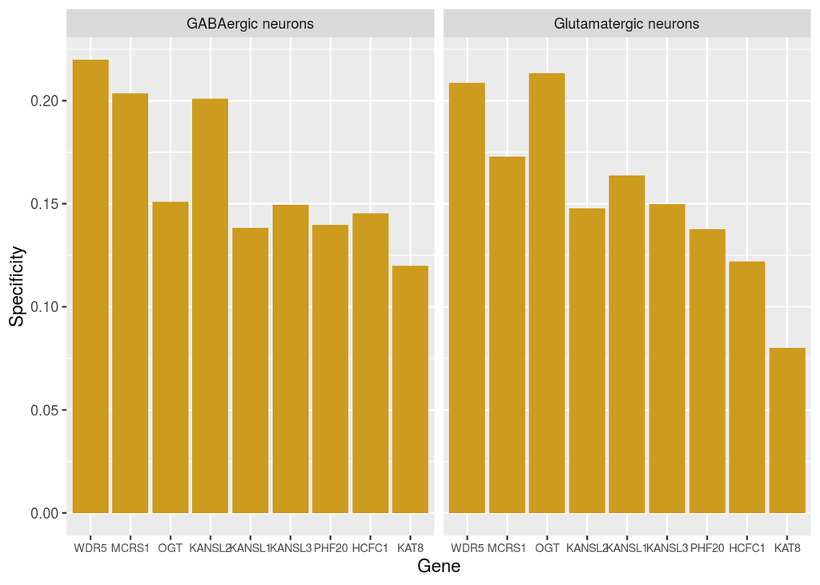

```r
# Plot just MTG neurons
specificity %>%
  dplyr::filter(Study == "Medial temporal gyrus") %>%
  dplyr::filter(CellType %in% c("Dopaminergic neurons", "GABAergic neurons", "Glutamatergic neurons")) %>%
  ggplot(aes(x = reorder_within(x = Gene,
                                by = Specificity,
                                within = Study,
                                fun = median,
                                desc = TRUE),
             y = Specificity)) +
  geom_col(fill = "goldenrod3") +
  scale_x_reordered() +
  facet_wrap(~ CellType, scales = "free_x") +
  labs(x = "Gene") +
  theme(axis.text.x = element_text(size = 7))
```

## Enrichment tests

Recent updates to the `EWCE` package have rendered some of Regina's functions and all of the specificity matrices unusable for the enrichment analysis. It also requires a more up to date version of `R` than is installed on the server. Thus, the new package version must be run via a docker and use newly generated matrices. So far Regina has regenerated the Allen Brain Atlas matrix.